# Оценка износа футеровок металургического ковша посредством контроля датчиками внешней температуры обшивки.

## Описание проекта

На металлургическом предприятии используются ёмкости для жидкого металла, футерованные огнеупорным кирпичом. Со временем футеровка изнашивается, её приходится менять на новую. Для целей контроля температуры технологи установили под днищем каждой ёмкости по 20 датчиков, в настоящий момент они смотрят на абсолютную температуру каждого из них – она не должна превышать 200 градусов.

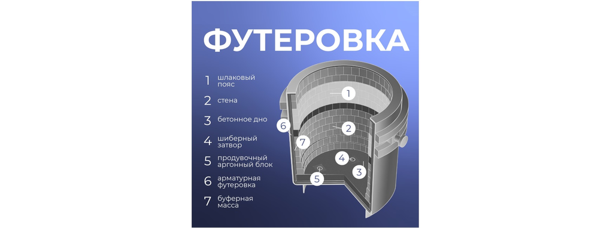

## Проверка гипотез

**Гипотеза 1:**

Гипотеза о выявлении нарушений в тепловом балансе посредством контроля температуры внешнего слоя футеровок. Превышения допустимого порога температуры (200°С) потребует замену футеровок.

**Гипотеза 2:**

Гипотеза о выявлении аномальных значений или отсутствие таковых с показаний датчиков температуры, что может свидетельствовать об их поломке и необходимости замены. Несвоевременная замена датчиков температуры может привести к отсутствию наличия основного признака разрушения футеровок.

## Описание данных

Предполагается наличие дата-сета: исторические значения датчиков за несколько лет, дополнительная информация отсутствует.

Для моделирования создадим искуственно данные о температуре в диапазоне от `160` до `205` градусов. Заменим значение температуры `160` на `0`. Это будет моделирование поломки датчика температуры.

В файле столбец `партия` содержит номер партии.

```python
from IPython.core.display import display, HTML
display(HTML("<style>.container { width:90% !important; }</style>"))
```

```python
import warnings
warnings.filterwarnings('ignore')
```

## Для моделирования создадим искуственно дата-сет данных

```python
import pandas as pd
from numpy import random
```

```python
x = random.randint(160,205, size=(1000, 21))
temp_sensor = pd.DataFrame(x)
temp_sensor.reset_index(inplace= True)
temp_sensor.rename(columns = {'index':'партия'}, inplace = True )
temp_sensor.drop (temp_sensor.columns [[1]], axis= 1 , inplace= True )
temp_sensor = temp_sensor.replace(160,0)
display(temp_sensor.head(10).style.background_gradient(cmap='Blues', axis=0).hide_index())
```

| партия | 1 | 2 | 3 | 4 | 5 | 6 | 7 | 8 | 9 | 10 | 11 | 12 | 13 | 14 | 15 | 16 | 17 | 18 | 19 | 20 |
| --- | --- | --- | --- | --- | --- | --- | --- | --- | --- | --- | --- | --- | --- | --- | --- | --- | --- | --- | --- | --- |
| 0 | 174 | 194 | 202 | 187 | 179 | 0 | 169 | 178 | 186 | 191 | 201 | 191 | 195 | 161 | 0 | 168 | 182 | 170 | 189 | 184 |
| 1 | 161 | 198 | 167 | 170 | 192 | 204 | 179 | 200 | 187 | 187 | 193 | 166 | 197 | 191 | 193 | 166 | 179 | 183 | 162 | 187 |
| 2 | 184 | 161 | 187 | 170 | 182 | 164 | 200 | 202 | 166 | 178 | 199 | 175 | 195 | 184 | 188 | 177 | 198 | 175 | 186 | 176 |
| 3 | 167 | 172 | 175 | 171 | 197 | 178 | 194 | 176 | 203 | 192 | 178 | 172 | 195 | 204 | 162 | 161 | 163 | 166 | 197 | 198 |
| 4 | 178 | 181 | 168 | 201 | 196 | 184 | 190 | 181 | 190 | 167 | 203 | 177 | 185 | 181 | 0 | 170 | 195 | 199 | 164 | 195 |
| 5 | 200 | 190 | 174 | 200 | 185 | 186 | 195 | 195 | 186 | 172 | 201 | 182 | 196 | 198 | 181 | 166 | 174 | 182 | 172 | 170 |
| 6 | 166 | 164 | 203 | 190 | 177 | 200 | 171 | 200 | 193 | 201 | 185 | 201 | 192 | 176 | 178 | 165 | 171 | 187 | 161 | 195 |
| 7 | 165 | 162 | 201 | 175 | 0 | 178 | 201 | 172 | 177 | 172 | 200 | 162 | 176 | 195 | 195 | 190 | 204 | 185 | 170 | 178 |
| 8 | 193 | 179 | 192 | 177 | 162 | 189 | 169 | 202 | 169 | 192 | 170 | 203 | 163 | 169 | 182 | 187 | 200 | 189 | 170 | 178 |
| 9 | 203 | 179 | 176 | 161 | 170 | 0 | 168 | 164 | 203 | 188 | 179 | 166 | 184 | 204 | 183 | 173 | 180 | 168 | 162 | 172 |

## Гипотеза 1: выявим партии и датчики с превышением температуры

```python
temp_sensor_max = pd.DataFrame(columns=['партия', 'номер датчика'])
for i in range(0, len(temp_sensor)):
    for j in range(1,20):
        if temp_sensor.loc[i, j]>200:
            temp_sensor_max.loc[len(temp_sensor_max.index)] = [i, j]
display(temp_sensor_max.head(10).style.background_gradient(cmap='Blues', axis=0).hide_index())
```

| партия | номер датчика |
| --- | --- |
| 0 | 3 |
| 0 | 11 |
| 1 | 6 |
| 2 | 8 |
| 3 | 9 |
| 3 | 14 |
| 4 | 4 |
| 4 | 11 |
| 5 | 11 |
| 6 | 3 |

## Гипотеза 2: выявим партии и датчики с ошибками в показаниях

```python
temp_sensor_defect = pd.DataFrame(columns=['партия', 'номер датчика'])
for i in range(0, len(temp_sensor)):
    for j in range(1,20):
        if temp_sensor.loc[i, j]==0:
            temp_sensor_defect.loc[len(temp_sensor_defect.index)] = [i, j]
display(temp_sensor_defect.head(10).style.background_gradient(cmap='Blues', axis=0).hide_index())
```

| партия | номер датчика |
| --- | --- |
| 0 | 6 |
| 0 | 15 |
| 4 | 15 |
| 7 | 5 |
| 9 | 6 |
| 10 | 4 |
| 15 | 17 |
| 21 | 15 |
| 21 | 19 |
| 22 | 14 |

## Вывод

- создали искуственно дада-сет итимитирующий показания с 20 датчиков.
- выявили данные о превышении температуры показаний датчиков и занесли в таблицу `temp_sensor_max` данные о партии и соответствующем номере датчика.
- выявили данные о вышедших из строя датчиков и занесли в таблицу `temp_sensor_defect` данные о партии и соответствующем номере датчика.

**По условию поставленной задачи имеются данные только о исторических значениях датчиков за несколько лет и дополнительная информация отсутствует. Если в дополнении к этим данным была бы информация с подтверждением наличия разрушений в футеровок, то мы могли бы на имеющихся исторических данных построить и обучить модель предсказания по имеющимся признакам наличие разрушений в футеровок и необходимости их замены.**